# Контроль качества данных эксперимента 3

**Статус:** техническая инвентаризация и диагностический ноутбук реокардиомонитора РНЦХ. Функции сердца здесь не рассчитываются.

Паспорт серии приведён в `10.10`. Дата остаётся открытым полем до сверки с первичным протоколом. Постороннее исследование на другом приборе не включается: ноутбук обрабатывает только записи, явно перечисленные во внешней конфигурации.

Численные наблюдения перепроверены 27.08.2026 по четырём основным CSV из локальной конфигурации и их полным контрольным суммам. Сохранённые выводы ячеек очищены. Обезличенная подробная сводка хранится во внешнем `derived_root` в `exp03/qc/10.11_primary_signal_diagnostic.candidate.json` со статусом `pending_manual_review`.

Исторические дыхательные интервалы используются только как гипотезы для повторного просмотра. В `11.11` сохранены кандидатные интервалы `14-09-42` и `14-19-52`; для `14-07-01` полный кандидат не обоснован, а `14-17-16` исключена как технический тест. Командных меток нет, поэтому ни один кандидат не становится количественной разметкой до явного решения автора, основанного на памяти о протоколе и форме сигнала.

## 1. Инвентаризация и соответствие файлов

В анализ входят только обезличенные `record_id`, явно перечисленные в `KALMYKOV_EXP03_CONFIG`. Относительный путь обязан находиться внутри разрешённого `csv_subdir`. Остальные CSV учитываются только числом при проверке полноты конфигурации и не анализируются.

Полный SHA-256 определяет байт-в-байт совпадающие записи. Канонический файл задаётся конфигурацией, а не выбирается автоматически по длине пути.

| Запись | Роль | Ссылка на протокол | Ожидаемые активные каналы | Длительность, с | Частота, Гц | Копий в разрешённой области | SHA-256, начало |
| --- | --- | --- | --- | --- | --- | --- | --- |
| exp03_ttrkg_only | ttrkg_channel_1_only | 10.11_content_check_time_label_14-07-01_primary_protocol_confirmation_pending | [1] | 67.420000 | 200.000000 | 2 | 33d16fb8eadc6191 |
| exp03_side_only | side_channel_2_only | 10.11_content_check_time_label_14-09-42_primary_protocol_confirmation_pending | [2] | 69.220000 | 200.000000 | 2 | 32028026676c9e57 |
| exp03_switch_test | channel_switch_test | 10.11_content_check_time_label_14-17-16_primary_protocol_confirmation_pending | [1, 2] | 46.020000 | 200.000000 | 2 | d686dbed499bee01 |
| exp03_both_breathing | both_channels_breathing | 10.11_content_check_time_label_14-19-52_primary_protocol_confirmation_pending | [1, 2] | 73.620000 | 200.000000 | 2 | 6ac8036b75979baf |

```
Явно включено записей: 4
Других CSV в разрешённой области: 7
Неуказанные CSV не анализируются.
```

### Результат файловой проверки

- запись `14-07-01` соответствует отдельному каналу 1, ТТРКГ;
- запись `14-09-42` соответствует отдельному каналу 2, боковой сборке;
- запись `14-17-16` содержит поочерёдное отключение каналов, тогда как в текстовом протоколе для этой пробы указано 14:08;
- запись `14-19-52` содержит совместную дыхательную регистрацию, тогда как в текстовом протоколе указано 14:17;
- четыре основные записи имели байт-в-байт копии в двух каталогах разрешённой области данных.

Повторная проверка подтвердила соответствие назначенных ролей фактическим состояниям каналов по техническому порогу `BASE > 5 Ом`. Установленное несоответствие двух временных обозначений не объясняется. Соответствие записей протокольным пробам можно уточнять по первичному журналу, но временных меток дыхательных команд нет ни в журнале данных, ни в CSV. Последовательность и границы режимов принимаются только после авторской реконструкции по памяти и форме сигнала. Дата эксперимента по этим временам не определяется.

## 2. Отдельная запись ТТРКГ, канал 1

Назначение файла и работа только канала 1 подтверждены. Исторические границы 0, 30, 45, 53 и 67,42 с повторно сопоставлены с `BASE1`. Форма сигнала поддерживает лишь общий переход к более нестационарному участку после 30 с и восстановление около 53–54 с; границы 45 и 53 с не имеют самостоятельного надёжного подтверждения. Полная кандидатная последовательность дыхательных режимов не формируется, `mode_sequence` остаётся пустой. Это отрицательное решение зафиксировано в `11.11` как отсутствие обоснованного размеченного кандидата.

| Канал | BASE median, Ом | BASE p01–p99, Ом | QS median, Ом | QS max, Ом | RHEO p01–p99, мОм |
| --- | --- | --- | --- | --- | --- |
| 1 | 101.350000 | 100.29–102.49 | 4700.000000 | 4700.000000 | -584.5–584.2 |

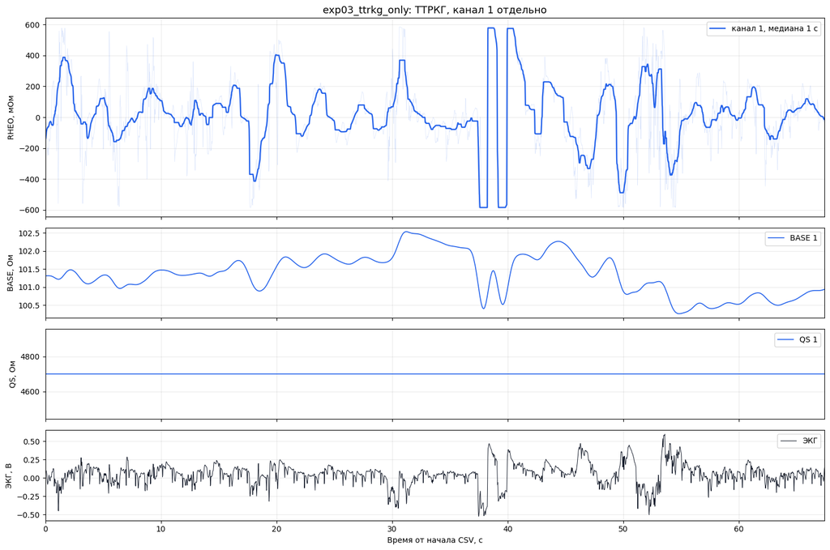

**Диагностическое наблюдение.** Медиана `BASE1` равна 101,353 Ом, тогда как в примечании протокола указано около 80 Ом. `QS1` сохраняет значение 4700 Ом на протяжении всей записи. Физический смысл этого кода и статус предела шкалы не установлены.

В `RHEO1` повторяются уровни около −584,501 и +584,215 мОм. Доля наиболее частых дискретных крайних уровней составляет 3,26 % отсчётов, а самый длинный непрерывный участок — 0,57 с. Это наблюдение о записанных числах. Насыщение измерительного тракта остаётся гипотезой; запись требует расшифровки `QS` и проверки диапазона `RHEO`.

## 3. Отдельная запись боковой сборки, канал 2

Назначение файла и работа только канала 2 подтверждены. Повторный просмотр `BASE2` поддерживает кандидатные границы 0, 30, 49, 59 и 69,22 с. В `11.11` им предварительно сопоставлены спокойное дыхание, вдох с задержкой, форсированное дыхание и задержка после выдоха. Физиологические названия и точные секунды не зарегистрированы прибором, поэтому разметка имеет статус кандидата, ожидающего ручного принятия. До принятия её нельзя передавать в количественный анализ.

| Канал | BASE median, Ом | BASE p01–p99, Ом | QS median, Ом | QS max, Ом | RHEO p01–p99, мОм |
| --- | --- | --- | --- | --- | --- |
| 2 | 37.160000 | 35.95–40.08 | 343.000000 | 372.000000 | -505.7–505.4 |

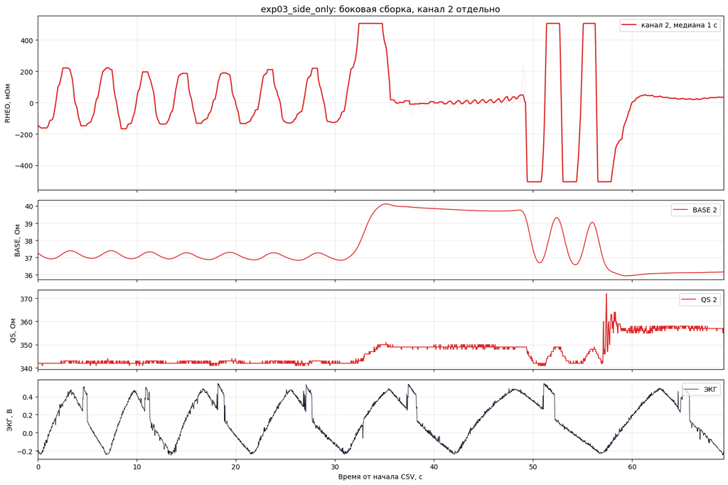

**Диагностическое наблюдение.** Медиана `BASE2` равна 37,158 Ом и близка к значению 36 Ом из протокола. `QS2` находится около 343 Ом и не принимает значение 4700 Ом. `BASE1` равен нулю, что согласуется с отключением канала 1. Близость базового уровня протоколу не заменяет калибровку прибора.

В `RHEO2` уровни около −505,679 и +505,432 мОм занимают 12,44 % отсчётов; самый длинный непрерывный участок длится 2,31 с. До проверки измерительного тракта эти участки нельзя использовать для оценки дыхательной или пульсовой амплитуды. Причина повторения крайних уровней не установлена.

## 4. Запись поочерёдного отключения каналов

Кандидатные состояния определяются по порогу `BASE`, заданному во внешней конфигурации. Порог является техническим правилом сегментации, а не физическим критерием исправности. Переходы и подписи состояний должны быть проверены по протоколу до использования численных различий.

Запись является техническим тестом и исключена из дыхательной разметки серии `11.11`: переходы `BASE` отражают прежде всего изменение состояния каналов.

| Начало, с | Конец, с | Активны по порогу | BASE1 median, Ом | BASE2 median, Ом | QS1 median, Ом | QS2 median, Ом |
| --- | --- | --- | --- | --- | --- | --- |
| 0.000000 | 12.080000 | оба | 54.160000 | 40.860000 | 1371.000000 | 368.000000 |
| 12.080000 | 22.990000 | только 2 | 0.000000 | 36.880000 | 4700.000000 | 357.000000 |
| 23.000000 | 34.020000 | оба | 54.190000 | 40.900000 | 1284.000000 | 368.000000 |
| 34.030000 | 42.800000 | только 1 | 92.690000 | 0.000000 | 4700.000000 | 4700.000000 |
| 42.810000 | 46.020000 | оба | 54.330000 | 33.360000 | 1280.000000 | 368.000000 |

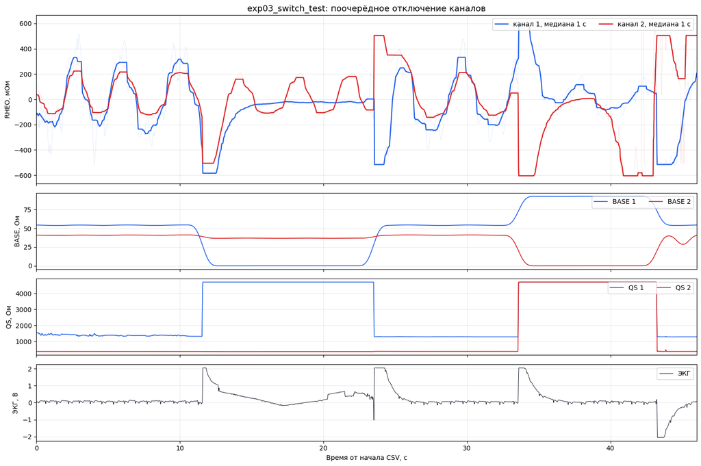

**Диагностическое наблюдение.** Технические состояния по `BASE > 5 Ом` образуют последовательность: оба канала 0,000–12,075 с; только канал 2 12,080–22,990 с; оба канала 22,995–34,025 с; только канал 1 34,030–42,805 с; оба канала 42,810–46,020 с. В последнем интервале длительностью 3,21 с оценка менее устойчива и не проходит установленный минимум 4 с.

При совместной работе медианы составляют приблизительно `BASE1=54,2 Ом` и `BASE2=40,9 Ом`. После отключения канала 1 `BASE2` остаётся около 36,9 Ом; после отключения канала 2 `BASE1` возрастает примерно до 92,7 Ом. Зависимость базового уровня оставшегося канала от состояния соседнего подтверждается без ЭКГ-разметки. Причина эффекта не определена.

Повторяющиеся крайние уровни занимают 3,45 % отсчётов `RHEO1` и 5,98 % отсчётов `RHEO2`; непрерывные участки достигают 0,91 и 1,03 с. Поэтому пульсовые амплитуды внутри этих интервалов пока не являются принятым результатом. Значение `QS=4700` встречается у отключённого канала и у канала 1 при одиночной работе, однако его физическая интерпретация неизвестна.

## 5. Совместная запись обоих каналов с дыхательными манёврами

Работа обоих каналов на всей записи подтверждена. В `11.11` сохранена кандидатная последовательность: 0–30 с — спокойное дыхание; 30–46 с — вдох и задержка; 46–57 с — форсированное дыхание; 57–73,62 с — задержка после выдоха. Границы перенесены из исторического ноутбука 16 и повторно сопоставлены с `BASE1` и `BASE2`, но событийных меток команд нет. Поэтому эта разметка ожидает ручного принятия и не является непосредственно измеренной шкалой режимов.

| Канал | BASE median, Ом | BASE p01–p99, Ом | QS median, Ом | QS max, Ом | RHEO p01–p99, мОм |
| --- | --- | --- | --- | --- | --- |
| 1 | 54.420000 | 52.96–58.22 | 1307.000000 | 1584.000000 | -516.8–516.1 |
| 2 | 40.720000 | 39.65–44.19 | 368.000000 | 372.000000 | -505.7–505.4 |

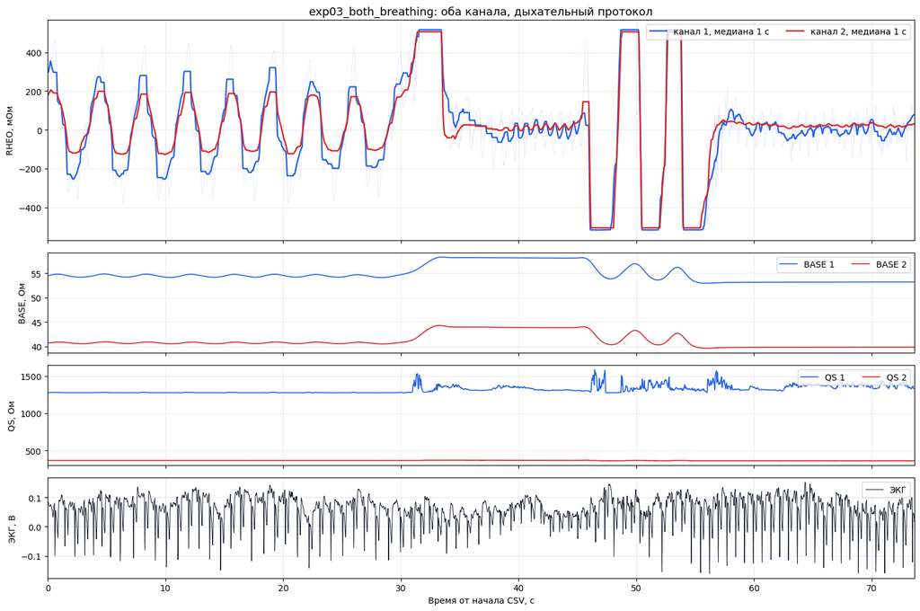

| Канал | Начало, с | Конец, с | Длительность, с | Уровень RHEO, мОм | Граница диапазона |
| --- | --- | --- | --- | --- | --- |
| 1 | 31.800000 | 32.805000 | 1.005000 | 515.717000 | верхняя |
| 1 | 33.280000 | 33.405000 | 0.125000 | 516.217000 | верхняя |
| 1 | 47.400000 | 47.785000 | 0.385000 | -515.470000 | нижняя |
| 1 | 48.920000 | 49.065000 | 0.145000 | 515.717000 | верхняя |
| 1 | 49.100000 | 49.205000 | 0.105000 | 516.178000 | верхняя |
| 1 | 49.260000 | 49.545000 | 0.285000 | 515.717000 | верхняя |
| 1 | 49.600000 | 49.745000 | 0.145000 | 515.717000 | верхняя |
| 1 | 49.800000 | 50.185000 | 0.385000 | 515.717000 | верхняя |
| 1 | 50.780000 | 50.965000 | 0.185000 | -515.969000 | нижняя |
| 1 | 52.980000 | 53.325000 | 0.345000 | 515.717000 | верхняя |
| 1 | 53.420000 | 53.785000 | 0.365000 | 515.717000 | верхняя |
| 1 | 54.300000 | 54.725000 | 0.425000 | -515.969000 | нижняя |
| 1 | 54.780000 | 55.405000 | 0.625000 | -515.969000 | нижняя |
| 1 | 55.600000 | 55.725000 | 0.125000 | -515.969000 | нижняя |
| 2 | 31.420000 | 32.865000 | 1.445000 | 505.432000 | верхняя |
| 2 | 32.920000 | 33.425000 | 0.505000 | 505.432000 | верхняя |
| 2 | 46.160000 | 48.045000 | 1.885000 | -505.679000 | нижняя |
| 2 | 48.780000 | 50.185000 | 1.405000 | 505.432000 | верхняя |
| 2 | 50.480000 | 51.965000 | 1.485000 | -505.679000 | нижняя |
| 2 | 52.700000 | 53.765000 | 1.065000 | 505.432000 | верхняя |
| 2 | 53.980000 | 55.425000 | 1.445000 | -505.679000 | нижняя |

| Интервал-кандидат | Начало, с | Конец, с | Канал | Плоские крайние отсчёты, % | Статус амплитуды |
| --- | --- | --- | --- | --- | --- |
| спокойное дыхание | 0.000000 | 30.000000 | 1 | 0.000000 | этот критерий не блокирует; остальные проверки обязательны |
| спокойное дыхание | 0.000000 | 30.000000 | 2 | 0.000000 | этот критерий не блокирует; остальные проверки обязательны |
| вдох и задержка | 30.000000 | 46.000000 | 1 | 7.060000 | амплитуда полного интервала не принимается; требуется чистое подокно |
| вдох и задержка | 30.000000 | 46.000000 | 2 | 12.190000 | амплитуда полного интервала не принимается; требуется чистое подокно |
| форсированное дыхание | 46.000000 | 57.000000 | 1 | 32.000000 | амплитуда полного интервала не принимается; требуется чистое подокно |
| форсированное дыхание | 46.000000 | 57.000000 | 2 | 66.230000 | амплитуда полного интервала не принимается; требуется чистое подокно |
| задержка после выдоха | 57.000000 | 73.622000 | 1 | 0.000000 | этот критерий не блокирует; остальные проверки обязательны |
| задержка после выдоха | 57.000000 | 73.622000 | 2 | 0.000000 | этот критерий не блокирует; остальные проверки обязательны |

```
Кандидатная маска исключения: C:\Users\ELVIS_NIX\AppData\Local\Temp\phd-all-notebooks-27jvspzs\derived\exp03\qc\10.11_exp03_both_breathing_signal_mask.candidate.json
```

**Диагностическое наблюдение.** Оба канала активны по техническому порогу `BASE > 5 Ом` на протяжении всей записи. Медианы равны `BASE1=54,419 Ом` и `BASE2=40,717 Ом`; второй уровень близок к протокольному, первый ниже указанного значения 60 Ом. `QS1` изменяется от 1272 до 1584 Ом при медиане 1307 Ом, а `QS2` — от 362 до 372 Ом при медиане 368 Ом. Код 4700 Ом в этой записи не встречается. Физическая интерпретация `QS` и метрологический статус шкал всё равно остаются неизвестными.

Для воспроизводимого поиска подозрительных участков введён диагностический критерий: значение `RHEO` должно оставаться в точности постоянным не менее 0,10 с и находиться в однопроцентной полосе у одного из двух наблюдаемых пределов диапазона записи. Порог 1 % и длительность 0,10 с являются правилами диагностического контроля качества, а не паспортными характеристиками прибора. Обнаружение такого участка подтверждает плоский крайний фрагмент в CSV, но само по себе не доказывает насыщение измерительного тракта.

По этому критерию плоские крайние фрагменты занимают 6,32 % отсчётов `RHEO1` и 12,54 % отсчётов `RHEO2`; их максимальная непрерывная длительность равна соответственно 1,01 и 1,89 с. Ранее сохранённые во внешней диагностической сводке версии 1 значения 6,88 и 12,58 % получены другим правилом — суммированием частот нескольких выбранных дискретных уровней. Эти две оценки нельзя смешивать; после принятия критерия эту сводку требуется пересчитать.

Сопоставление с кандидатной разметкой `11.11` даёт следующую картину:

- на участке 0–30 с критерий не обнаруживает плоских крайних фрагментов ни в одном канале;
- на участке 30–46 с они занимают 7,06 % `RHEO1` и 12,19 % `RHEO2`; основная группа приходится примерно на 31,4–33,4 с;
- на участке 46–57 с доли возрастают до 32,00 и 66,23 %, поэтому амплитуда полного интервала не подлежит количественной интерпретации;
- на участке 57–73,62 с критерий снова не обнаруживает таких фрагментов.

Отсутствие плоских крайних участков не означает автоматическую пригодность сигнала. Для интервалов 0–30 и 57–73,62 с всё ещё нужны принятая дыхательная и ЭКГ-разметка, калибровка и проверка воспроизводимости. Для 30–46 с допускается искать отдельное чистое подокно после 33,4 с, но нельзя вычислять амплитуду по полному интервалу. Фрагменты с плоскими крайними уровнями нельзя исправлять интерполяцией: истинная форма сигнала внутри них неизвестна.

При выполнении ноутбук сохраняет обезличенную интервальную маску и параметры критерия во внешнем производном файле `exp03/qc/10.11_exp03_both_breathing_signal_mask.candidate.json`. Его статус остаётся `pending_manual_review`; файл не разрешает количественный анализ автоматически.

## 6. Диагностическая проверка автоматических ЭКГ-кандидатов

Для сопоставления с архивным расчётом воспроизведён детектор текущей серии `11.12` с параметрами локальной конфигурации. Кандидатный набор характеризуют число событий, частота по числу событий, частота по медиане RR и максимальный интервал RR. Эти показатели не являются принятой ЭКГ-разметкой.

| Запись | Кандидаты R | Частота по числу, уд/мин | Частота по медиане RR, уд/мин | Максимальный RR, с |
| --- | --- | --- | --- | --- |
| `14-07-01` | 71 | 63,2 | 76,9 | 3,62 |
| `14-09-42` | 24 | 20,8 | 49,6 | 10,46 |
| `14-17-16` | 4 | 5,2 | 6,0 | 11,96 |
| `14-19-52` | 80 | 65,2 | 75,0 | 5,66 |

Во всех наборах имеются длинные пропуски. Для записи `14-19-52` алгоритм выбрал отрицательные отклонения ЭКГ и сформировал 80 кандидатов. Это вычислительная полярность, а не подтверждение физиологической природы каждого события. В кандидатном списке остаются интервалы без событий 37,54–39,36; 39,36–45,02 и 45,02–46,54 с; центральный пропуск длится 5,66 с. Следовательно, этот список неполон и пока непригоден для разбиения `RHEO` на сердечные циклы. Сам канал ЭКГ на этом основании не объявляется непригодным: требуется ручной просмотр исходной формы в серии `11.12`.

В записи `14-17-16` четыре автоматических события находятся не далее 0,57 с от границ технических состояний каналов, поэтому их нельзя принимать как R-зубцы без ручной проверки. Ни один сопроводительный файл ЭКГ не имеет статуса `accepted`.

Архивный детектор `40.90` воспроизводит прежние количества 72, 72, 40 и 70 событий, но максимальные RR остаются равными 7,18; 5,26; 7,59 и 14,84 с. Следовательно, старый критерий по числу событий и медианной частоте пропускал длинные участки без надёжной детекции. Старые ансамблевые амплитуды и вывод о сердечном происхождении не подтверждены.

## 7. Выводы и границы результата

### Подтверждённые файловые и экспериментальные факты

1. В разрешённой области данных обнаружены байт-в-байт копии четырёх основных записей; расчёт должен использовать каждый полный SHA-256 один раз.
2. Назначенные роли четырёх основных записей совпадают с фактическими состояниями каналов по техническому порогу `BASE > 5 Ом`.
3. В записи поочерёдного отключения базовый уровень оставшегося канала зависит от состояния другого канала. Механизм эффекта не установлен.
4. Временные обозначения двух записей не совпадают с текстовым протоколом.
5. Постороннее несинхронное исследование на другом приборе не относится к эксперименту 3.

### Диагностические наблюдения

- во всех активных `RHEO` основных записей имеются продолжительные повторения дискретных крайних уровней; для `14-19-52` их интервальная локализация воспроизведена отдельным критерием, а насыщение остаётся гипотезой;
- в `14-19-52` интервал 46–57 с нельзя использовать для количественной амплитуды обоих каналов, полный интервал 30–46 с также требует выделения чистого подокна; отсутствие найденных плато на 0–30 и 57–73,62 с не заменяет остальных проверок;
- автоматические ЭКГ-кандидаты текущего и архивного детекторов содержат длинные пропуски и не приняты вручную;
- отдельная запись канала 2 имеет `BASE2`, близкий к протокольному значению, и стабильный `QS2` без значения 4700 Ом;
- отдельная запись канала 1 имеет `BASE1` выше протокольного значения и постоянный код `QS1=4700 Ом`; физический смысл этого кода не установлен.

### Требования к продолжению

1. Сверить дату и назначение файлов по первичному журналу. По текущему решению автора кандидатные интервалы `11.11` остаются в статусе `pending_manual_review`; `accepted_modes` не заполняются и количественные расчёты по режимам не выполняются.
2. Проверить `QS`, пределы диапазона, калибровку `BASE/RHEO` и межканальное влияние по отдельному аппаратному протоколу.
3. Выполнить ручную ЭКГ-разметку с явным контролем пропусков, ложных событий и участков переключения каналов.
4. Только после принятия сопроводительных файлов дыхания и ЭКГ повторить пульсовые ансамбли и сравнение конфигураций. Числа архивного `40.90` до этого не использовать.
5. Числа версии РНЦХ не использовать как поправку для версии МГТУ.

```
10.11 file_qc_status: pending_manual_review
Основных включённых записей: 4
Неклассифицированных уникальных записей: 3
Кандидатный манифест: C:\Users\ELVIS_NIX\AppData\Local\Temp\phd-all-notebooks-27jvspzs\derived\exp03\qc\10.11_record_manifest.candidate.json
```

## Производный манифест записей

Последующие расчёты серии 40 принимают только обезличенный манифест контроля качества (QC) по схеме `schemas/record_manifest.schema.json`. Он должен фиксировать точный `record_id`, SHA-256 исходной записи, добровольца, конфигурацию, монтаж, размер боковой сборки и **фактически**, а не ожидаемо активные каналы. До ручного принятия такого манифеста реальный расчёт серии 40 блокируется.